# Praca domowa 2

Jan Lis

## Dane

Dane wykorzystane w Pracy domowej 2 dotyczą wyników egzaminów z 3 umiejętności: czytania, pisania i operacji matematycznych. Dodatkowo dostępne są podstawowe informacje o studentach i ich rodzicach. Opis wszystkich kolumn znajduje się również w pliku `README.md`.

| Zmienna | Opis |
| --- | --- |
| **gender** | płeć |
| **race.ethnicity** | pochodzenie etniczne |
| **parental.level.of.education** | wykształcenie rodziców |
| **lunch** | jaki obiad jedli uczniowie w dniu egzaminu |
| **test.preparation.course** | czy uczeń odbył kurs przygotowujący |
| **math.score** | wynik egzaminu z matematyki |
| **reading.score** | wynik egzaminu z czytania |
| **writing.score** | wynik egzaminu z pisania |

## Zadanie 1

Jak wyglądają rozkłady wyników uczniów z trzech przedmiotów (matematyka, czytanie, pisanie)?

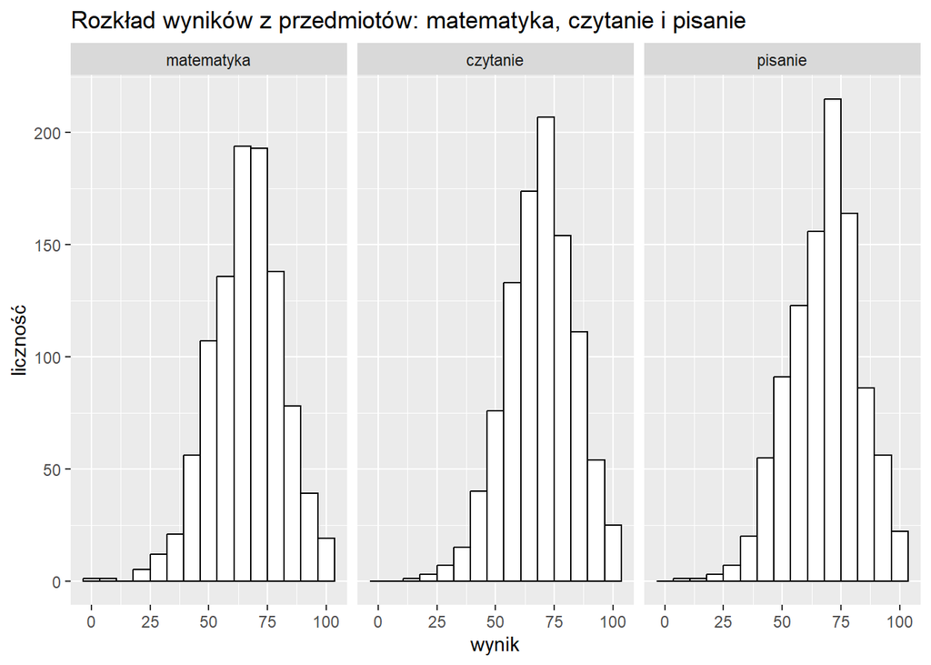

```r
# Tu umieść kod do wygenerowania odpowiedzi do zadania.

etykiety<-c("matematyka","czytanie","pisanie")
names(etykiety) <- c("math.score","reading.score","writing.score")

plot1<-df %>% select(math.score, reading.score,writing.score) %>%
  pivot_longer(cols=everything(), names_to="przedmiot", values_to="wynik") %>%
  ggplot(aes(x=wynik)) +
  facet_grid(~przedmiot, labeller = labeller(przedmiot=etykiety)) +
  geom_histogram(bins=15, color="black",fill="white") +
  labs(title="Rozkład wyników z przedmiotów: matematyka, czytanie i pisanie",
       x="wynik",y="liczność")
plot1
```

**Komentarz:**

Z matematyki najwięcej osób osiagnęło wynik ok. 65. Czytanie i pisanie mają bardzo podobne rozkłady z najbardziej popularnym wynikiem ok 70. Wyniki poniżej 25 punktów są sporadyczne. Ilość wyników szybko maleje przy ok 80 punktach. Są osoby, które osiągnły maksimum.

## Zadanie 2

Czy istnieje zauważalna różnica w wynikach między uczniami i uczennicami?

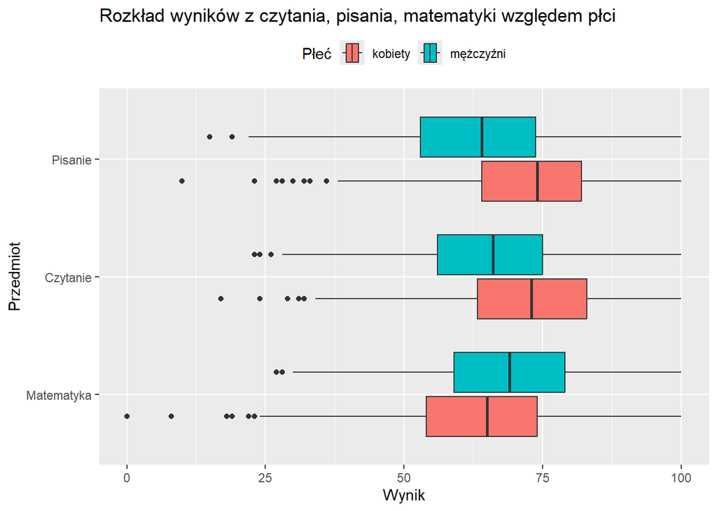

```r
# Tu umieść kod do wygenerowania odpowiedzi do zadania.

plot2 <- df %>% select(gender, math.score, reading.score,writing.score) %>%
  pivot_longer(cols=c(math.score,reading.score,writing.score),
               names_to="przedmiot", values_to = "wynik") %>%
  ggplot(aes(x=wynik, y=przedmiot, fill=gender))+geom_boxplot()+
  labs(title = "Rozkład wyników z czytania, pisania, matematyki względem płci",
       x="Wynik", y="Przedmiot", fill="Płeć") + theme(legend.position = "top")+
  scale_y_discrete(labels=c("Matematyka","Czytanie","Pisanie")) +
  scale_fill_discrete(labels=c("kobiety","mężczyźni"))
plot2
```

**Komentarz:** Patrząc na medianę wyników to kobiety poradziły sobie znacznie lepiej w pisaniu i czytania, natomiast trochę gorzej z matematyki. W każdej z kategorii pojawiły się osoby, które osiągnłęły maksymalne wyniki. Co interesujące do kobiet należą też najniższe wyniki, co może mieć związek z tym, że było ich więcej trochę więcej (518 do 482).

## Zadanie 3

Czy uczniowie, którzy ukończyli kurs przygotowawczy, osiągają lepsze wyniki niż pozostali?

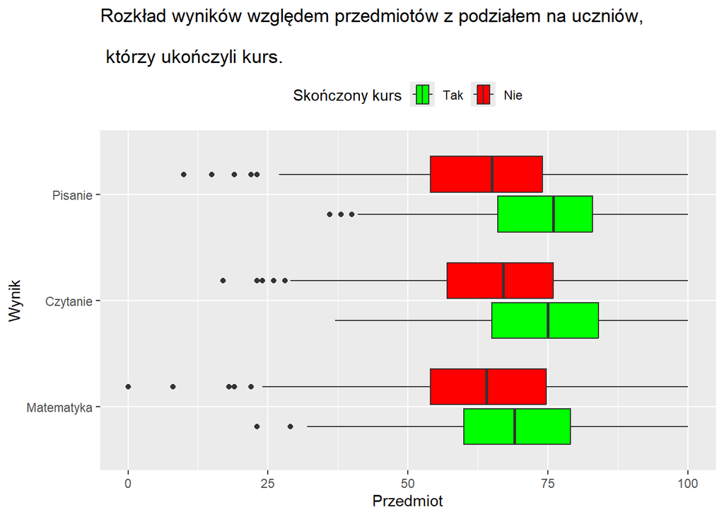

```r
# Tu umieść kod do wygenerowania odpowiedzi do zadania.

plot3 <-df %>% select(test.preparation.course,math.score,writing.score,reading.score) %>%
  pivot_longer(cols = c(reading.score,writing.score,math.score),
               names_to = "przedmiot", values_to = "wynik") %>%
  ggplot(aes(x=wynik,y=przedmiot, fill=test.preparation.course)) +geom_boxplot() +
  labs(title = "Rozkład wyników względem przedmiotów z podziałem na uczniów,
       \n którzy ukończyli kurs.", x = "Przedmiot", y="Wynik",fill="Skończony kurs")+
  theme(legend.position = "top") +
  scale_fill_discrete(labels=c("Tak","Nie"), palette = c("green","red")) +
  scale_y_discrete(labels=c("Matematyka","Czytanie","Pisanie"))
plot3
```

**Komentarz:** Patrząc na medianę w każdej kategorii to uczniowe,którzy ukończyli kurs osiągneli generalnie lepsze wyniki. Największą przewagę mieli w kategorii pisanie, a kurs miał najmniejszy efekt dla matematyki. W przypadku kursu lub jego braku dalej pojawili się uczniowie, którzy osiągnęli maksimum, jak i Ci, którzy osiągnęli bardzo niski wynik. Z uczniów, którzy osiągnęli niski wynik większość nie miała skończonego kursu.

## Zadanie 4

Jaki jest związek między poziomem wykształcenia rodziców a średnimi wynikami uczniów?

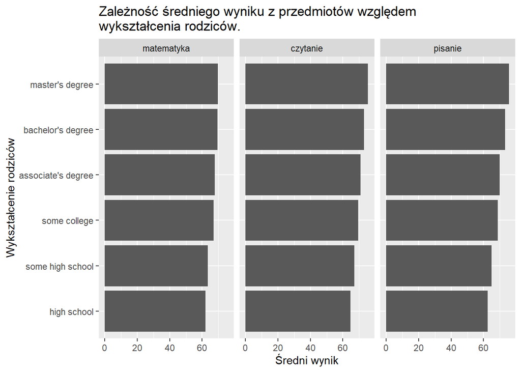

```r
# Tu umieść kod do wygenerowania odpowiedzi do zadania.


education_levels <- c("high school","some high school","some college",
                      "associate's degree","bachelor's degree",
                      "master's degree")

plot4<-df %>% select(parental.level.of.education, math.score,writing.score,reading.score) %>%
  mutate(parental.level.of.education=fct_relevel(parental.level.of.education, education_levels)) %>%
  pivot_longer(cols=c(math.score,writing.score,reading.score),
             names_to="przedmiot", values_to="wynik") %>%
  group_by(przedmiot, parental.level.of.education) %>%
  summarise(srednia=mean(wynik)) %>%
  ggplot(aes(y=parental.level.of.education,x=srednia))+
  facet_wrap(~przedmiot,labeller = labeller(przedmiot=etykiety)) + geom_col() +
  labs(title="Zależność średniego wyniku z przedmiotów względem\nwykształcenia rodziców.",
       x = "Średni wynik", y = "Wykształcenie rodziców")
plot4
```

**Komentarz:** Porównując średni wynik w zależności od przedmiotu do wykształceia rodziców widać, że wyższe wykształcenie rodziców skutkowało wyższym wynikiem dziecka. Różnica między tytułem magistra, a licencjatem jest jednak niewielka.

## Zadanie 5

Czy płeć i wykształcenie rodzica wpływa na wynik z matematyki?

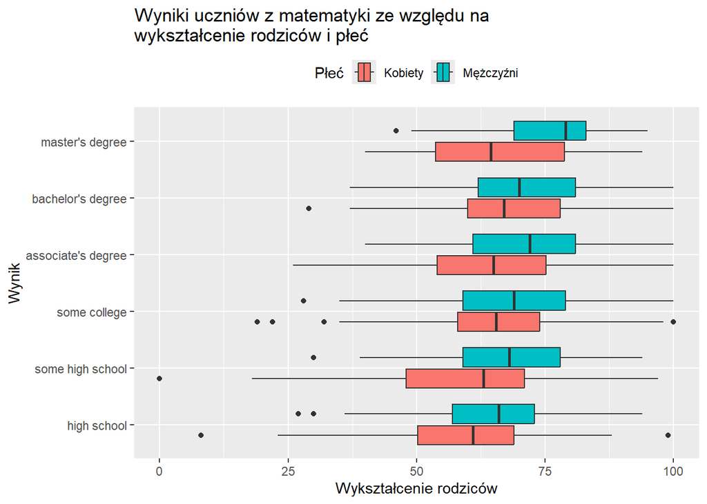

```r
# Tu umieść kod do wygenerowania odpowiedzi do zadania.

plot5<-df %>% select(gender,parental.level.of.education,math.score) %>%
  mutate(parental.level.of.education=fct_relevel(parental.level.of.education, education_levels)) %>%
  ggplot(aes(x=math.score,y=parental.level.of.education,fill=gender)) +
  geom_boxplot() +
  labs(title="Wyniki uczniów z matematyki ze względu na\nwykształcenie rodziców i płeć",
       x="Wykształcenie rodziców",y="Wynik",fill="Płeć") +
  theme(legend.position = "top")+
  scale_fill_discrete(labels=c("Kobiety","Mężczyźni"))
plot5
```

**Komentarz:** Niezależnie od wykształcenia rodziców chłopcy osiągnęli wyższą medianę wyników od dziewczyn. Dla dziweczyn mediana wyników względem wykształcenia rodziców jest na podobnym poziomie. Dla chłopców widać wzrost mediany wyników względem wyższego wykształcenia rodziców, z wyłączniem licencjatu. Dzieci, kórych rodzice mają tytuł magistra nie osiągnłęły maksymalengo wyniku, podczas gdy dla większości pozostałych kategorii odnotowano maksymalne wyniki. Widać też dla kategorii tytułu magistra, że “wąsy” wykresu są najmniejsze czyli rozkład ma mniej wartości krańcowych.

## Zadanie 6

Czy istnieje zależność między wynikami z matematyki a wynikami z czytania lub pisania

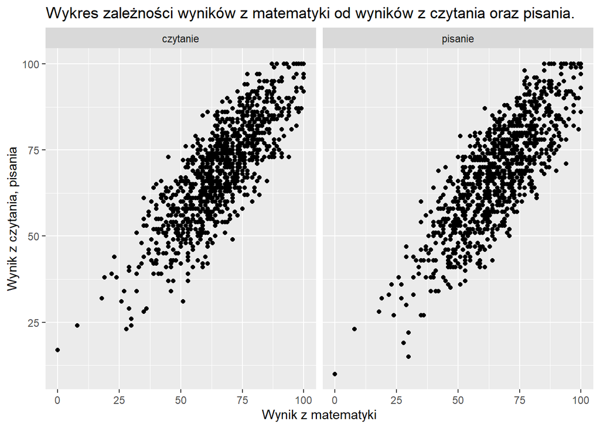

```r
# Tu umieść kod do wygenerowania odpowiedzi do zadania.

plot6<-df %>% select(math.score,reading.score,writing.score) %>%
  pivot_longer(cols=c(reading.score,writing.score),values_to = "wynik",names_to = "przedmiot") %>%
  ggplot(aes(x=math.score,y=wynik)) +
  facet_wrap(~przedmiot,labeller=labeller(przedmiot=c("reading.score"="czytanie",
                                                      "writing.score"="pisanie"))) +
  geom_point() +
  labs(title = "Wykres zależności wyników z matematyki od wyników z czytania oraz pisania.",
       y= "Wynik z czytania, pisania",x="Wynik z matematyki")
plot6
```

**Komentarz:**

Zależność wyników z matematyki od czytania lub pisania jest liniowa. Wraz z wyższym wynikiem z matematyki idzie w parze wyższy wynik z czytania lub pisania.